# Trust, but verify

How a skydiving weather dashboard was developed with AI agents

Amelia Miramonti · Lincoln AI meetup

November 2026

## What a weather app says

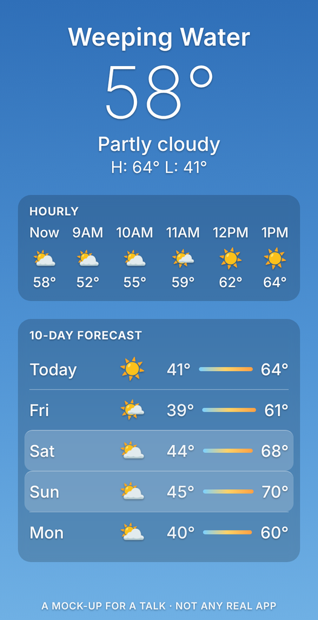

**Partly cloudy, Saturday and Sunday.** Highs in the sixties, seventy on Sunday. Nothing to decide.

That is the whole forecast, for most people.

So I asked my instructor whether we would be jumping.

The phone is a mock-up drawn for this talk, not any real app’s forecast.

C31

## Why I built it

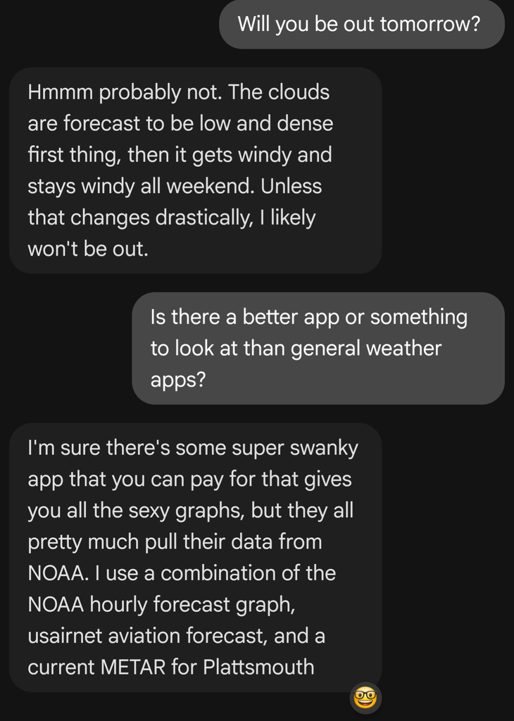

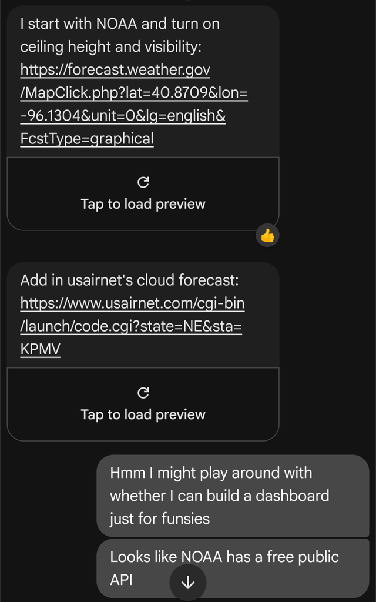

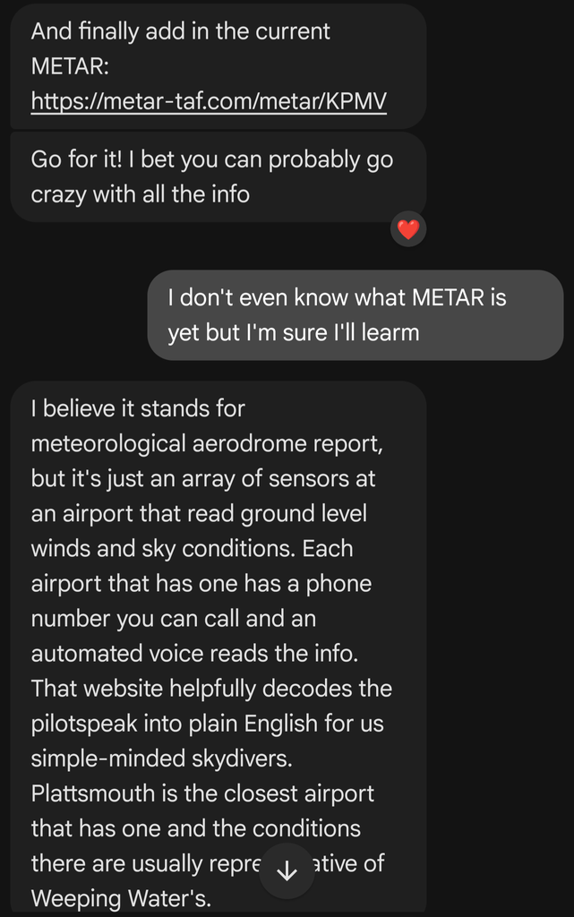

A text thread with my instructor, 2026: “Is there a better app?” The answer was three sites, read one by one. “I might play around with whether I can build a dashboard just for funsies.”

C30

## What a jumper needs to know

The partly-cloudy icon answered none of these:

- How low is the cloud at nine in the morning, and does it lift?
- What is the wind doing at 3,000 feet, and at the top of the climb?
- What will it gust to at noon, and against which limit?
- Is any of that still true by the second load?

A general app has no row for any of them. Three sites between them did, if you knew where to look and what the codes meant.

## The sites behind it

The club: [Lincoln Sport Parachute Club](https://skydivelspc.com/), Brown’s Airport, Weeping Water, Nebraska. Below, what a jumper there used to open one by one, and what the dashboard reads or is checked against; every other link is the one the live site offers. C37

**Read by the dashboard**

- [NWS forecast for the drop zone](https://forecast.weather.gov/MapClick.php?lat=40.8703&lon=-96.1085) (forecast.weather.gov)
- [KPMV observations, NWS](https://forecast.weather.gov/data/obhistory/KPMV.html) and [at the Iowa Environmental Mesonet](https://mesonet.agron.iastate.edu/sites/site.php?station=PMV&network=NE_ASOS)
- [Open-Meteo](https://open-meteo.com/), winds aloft, cloud cover and the 10-day outlook (CC BY 4.0)
- [TAFs at aviationweather.gov](https://aviationweather.gov/data/taf/?ids=KOFF%2CKOMA%2CKLNK)
- [NWS radar, KOAX](https://radar.weather.gov/station/KOAX/standard)

**Compared against, every day**

- [Mark Schulze’s Winds Aloft](https://www.markschulze.net/winds/?lat=40.8703&lon=-96.1085), the tool jumpers already use
- [usairnet, KPMV](https://www.usairnet.com/cgi-bin/launch/code.cgi?state=NE&sta=KPMV), a second decode of the same METAR
- [aviationweather.gov’s decoder](https://aviationweather.gov/data/metar/?ids=KPMV&hours=0), for the METAR and TAF parse
- [the USPA Skydiver’s Information Manual](https://www.uspa.org/sim), fingerprinted daily
- [the dashboard itself](https://amelia-m.github.io/lspc-weather/), loaded in a browser at three widths

C20, C26

## One of them, as it looks

[figure not shown]

**usairnet’s KPMV page**, its head: the latest report decoded, field by field. Further down the same page is its aviation forecast, cloud cover, wind, gusts, ceiling and the lowest cloud base every three hours for three days: the club’s cloud forecast before the dashboard. Still a second decode of the same METAR. C32

**Mark Schulze’s Winds Aloft** (no screenshot yet): direction and speed every thousand feet from the surface up, for a pin on his map. The winds-aloft table the dashboard reproduces, and is checked against nine times a day: eight scheduled runs and the daily check. C32

## Where exactly is the drop zone?

The app’s point for the drop zone, and Mark Schulze’s own pin for the club, both sat at 40.8675° N, 96.11° W: a field south-west of the runway, downhill from it. Nobody lands there. C33

On 8 October the point moved to the middle of the main landing area by the pea gravel (40.8703° N, 96.1085° W). Checked that day: the same Open-Meteo forecast cell and the same NWS gridpoint, so no forecast changed; only the ground the heights are measured from moved, 1,145 ft to 1,165 ft on the model’s terrain. C33

## What it is

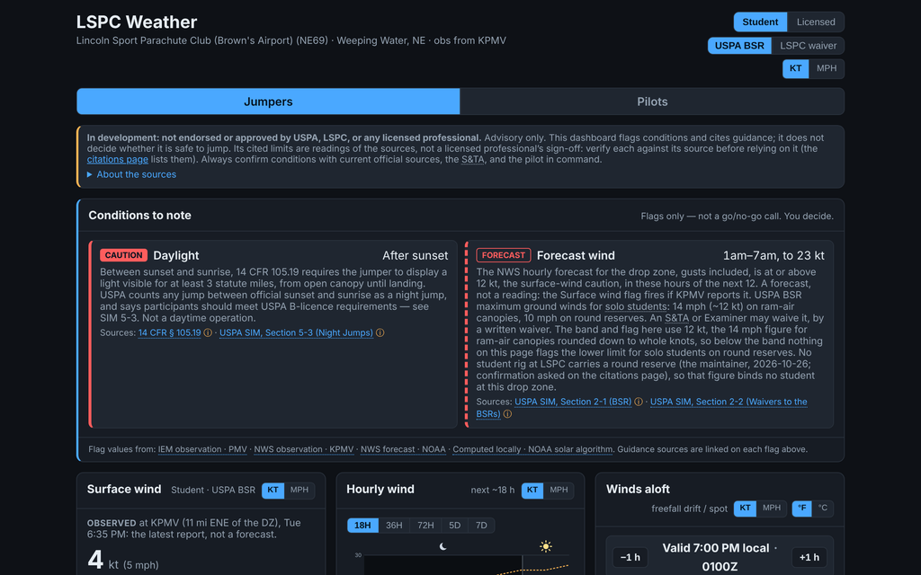

**LSPC Weather**: a weather dashboard for one drop zone, the Lincoln Sport Parachute Club at Brown’s Airport (NE69), Weeping Water, Nebraska.

- One page in place of a three-site routine: the NWS forecast, a cloud forecast and the KPMV METAR.
- Adds winds aloft for freefall drift and density altitude for the jump plane.
- Public, open source, on GitHub Pages. No account; the page reads public data in the browser, plus one small relay.

626 commits since 26 June 2026

## Why so many stations?

**The nearest report is not at the drop zone.** KPMV, Plattsmouth, is the closest station with a METAR: 11 mi east-north-east, on different ground. The Surface wind card says so in its first line. C34

**One report from two feeds.** The observation is read from the Iowa Environmental Mesonet first and the NWS second, and the newer wins: timed on 27 September, IEM had each report 4 to 6 minutes after it was taken, the NWS 24 to 33. C34

**The text, not the decode.** On 23 September the NWS served seven observations with an empty cloud decode under a 2,700 ft overcast. The sky is parsed from the METAR text first, and a daily check compares the parse with another decoder. C11

**Six METARs on the Pilots tab**: KPMV, Offutt, Omaha Eppley, Millard, Lincoln, Nebraska City, so a reader can see whether the sky at Plattsmouth is the region’s or Plattsmouth’s. C34

**Three TAFs in a chain.** KPMV issues none. The nearest is Offutt’s, written by the Air Force and carried on no feed a browser can read, so a relay fetches it; when it is missing, cancelled or ended, the card falls back to Omaha’s, then Lincoln’s, and says which it shows. C34

## The rule that shaped everything

From the working notes every agent reads first

> The dashboard never gives a go/no-go verdict. It flags a condition and hands the reader the rule behind it, so a human can check it and decide.

> A flag fires on a limit some published source sets, or on a plain observed fact, or it does not fire at all.

A threshold nobody published cannot be checked, so it gets no flag, no warning colour, no worded judgement. C6

Written down on 22 September, after four commits from 12 to 21 September that removed every number the app had invented. C7, C10

## What the rule threw out

Ceiling bands · dew-point spread · precipitation chance · forecast storm chance · gust spread · winds-aloft speed bands · density-altitude bands · the last-load countdown · every “watch” band · two colour highlights · a storm colour · a “fog favorable” verdict · a derived sky verdict C8

Each is listed in the notes by name, “so nobody reintroduces them believing they were an oversight.”

The one exception: a licensed jumper’s own limits, which the app always calls theirs. C24

## Six months, dated from the history

| when | what |
| --- | --- |
| 26 Jun | first commit; features through the summer (17, 20 and 25 commits a month) |
| 12 Sep | the citations page: every USPA and FAA claim, with what the source says |
| 19 to 21 Sep | the no-verdict rule; invented thresholds removed |
| 22 Sep | the working notes (CLAUDE.md) and the open-questions file begin |
| 23 to 24 Sep | a daily check compares the app’s METAR and TAF decoding with aviationweather.gov’s |
| Oct | samplers and archives: forecasts kept to score later, sources compared every few hours (399 commits) |
| 17 Oct | the deployed site loaded in a browser every day at three widths |
| 20 Oct | a relay for the Air Force base’s TAF, which no browser-readable feed carries |
| 5 Nov | the app’s own flag levels put to the club’s safety officer as a question |

C1, C2, C10

## Who did what

520 commits by a Claude agent, in four long sessions

91 by the project’s own workflows

13 by Amelia, who decided

31 dated decisions quoted in the notes C4, C5, C23

**Amelia decided.** Own thresholds on Licensed only (10 Oct). “Make it very clear” the wind card shows a report, not a forecast (30 Oct). Keep the sampler logging over seasons (30 Oct). Hold visibility to both rows of the rule (31 Oct). Findings logged durably (10 Nov). C24

**Agents worked under written rules.** Four gates before a push. Prove a new test by breaking the thing it names. Every finding goes in the repository in the same piece of work, and a hook repeats that on every prompt. Two commits came from an OpenAI agent. C22, C4

## What went wrong, and what each left behind

| the fault | what changed |
| --- | --- |
| 23 Sep: seven observations arrived with an empty cloud decode; the dashboard showed “Clear” and VFR under a 2,700 ft overcast. Found from a screenshot of the live site. C11 | The sky is read from the METAR text first. A daily check compares the app’s decode with another decoder’s. |
| usairnet redesigned its page; a comparison parsed nothing for 17 days, because it was built never to fail. C12 | A quiet comparison now shows as a count on the parity page, and the notes say to read it. |
| 28 Oct: GitHub’s runner image changed; the live-site check failed six times in two days before it started, and nobody read the issue. C13 | The runner is pinned. “A failing check that nobody reads is the same as no check.” |
| A button sat 3 px off a 320 px page, only in the half hour before midnight; the daily check ran in the morning. C14 | A second leg checks the fixture build with the clock at 11:45 PM. |
| 7 Nov: a runner died with an hour’s samples on it, unuploaded, and the next start was four hours off. C15 | One upload per sample; each run queues its successor. |

## Which hours are daytime?

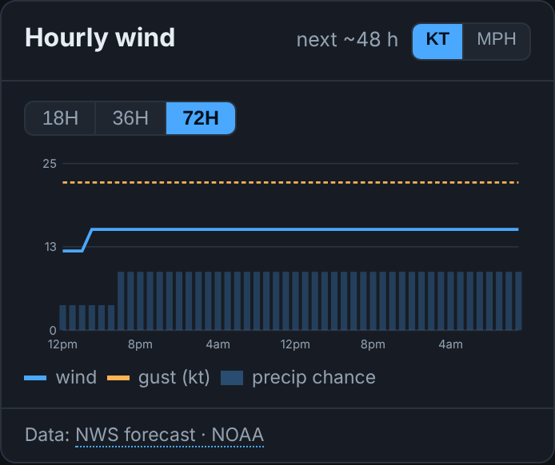

**Before 3 October**: two days of hourly wind, every hour drawn alike. Which stretches were daylight, when a jump could happen, took counting back from the axis.

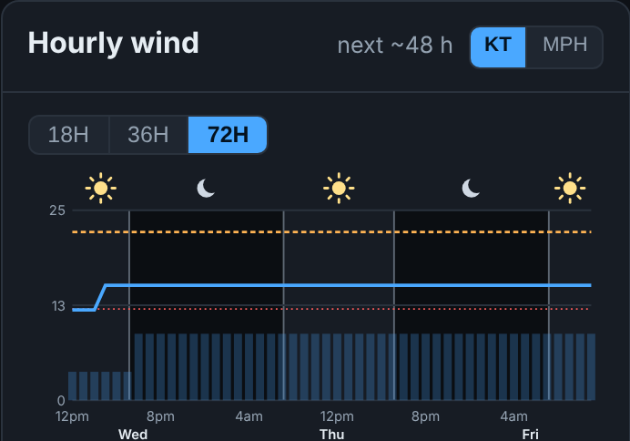

**Since**: night shaded darker than day, the sun and moon marking the turns, the weekday under each midnight, and the wind limit drawn where the flag reads it. C35

Both from the fixture build with the same 48 hours of data and the clock set to the same hour; the older code built with today’s fixture.

## Trusting, and skeptical

Skydivers are both: they trust the sources they already use, and they are skeptical of a new one. A dashboard that said something different from Mark Schulze’s page would be the one that was wrong. C36

So the first thing to show was sameness. The app’s winds-aloft table is built from the same Open-Meteo levels his tool reads; on the same hour the two agree within 4° and 1 kt at every altitude, and eight comparisons a day log it, with the observation’s decode set against usairnet’s the same way. C26, C36

Then, carefully, slightly better: three more levels below 1,000 ft for the canopy layer, which his table does not have; seven more pressure levels; the ground the heights are measured from; an “As Schulze” view kept exactly his method, so a reader can see the sameness and the difference apart. C36

## Checking the checkers

Two checks watch the project every day: a decoder comparison against aviationweather.gov and uspa.org, and the live site in a browser.

1 of 8 live-site failures was the site’s

Tallied on 7 November, every failure against what it turned out to be: C16

| check | failed | real | the check’s own | another host’s bad minute |
| --- | --- | --- | --- | --- |
| decoder comparison | 12 of 45 runs | 4 | 3 | 5 |
| live site | 8 of 148 runs | 1 | 6 (one cause) | 1 unexplained |

The five cries of wolf were each one bad answer from a server; one retry now covers four of the five kinds. uspa.org refused scripts for a day on 9 October and again on 9 November. C27

## The citations

Every USPA, CFR and FAA reference began as an AI recollection. C17

- Each was then read at its source: the USPA manual on 22 September and every cited part again on 8 October; the federal regulations on 23 September and again on 3 November.
- 19 citations; a page that shows, per claim, what the section says, when it was read, and what a reading could not settle. C18
- A daily check fingerprints every cited part, so a changed sentence at the source fails the daily check.
- The page takes an instructor’s answers. The review is still waiting on the club’s safety officer. C19

## AI disclosure

- **Tools**: Claude Code, in cloud sessions, with GitHub, a sandbox with a browser, and an allowlisted network. Two commits on 1 October came from an OpenAI code agent. C4
- **Models**, from the commit trailers: Claude Opus 5.5 on 296 commits, Claude Fable 5.1 on 137, Claude Opus 5 on 38, Claude Opus 4.8 on 22, Claude Haiku 4.5 on 2. C5
- **What they did**: wrote the code, the tests, the workflows and the notes; ran the comparisons; read the sources and recorded when; drafted this deck and its claims table.
- **How the work was reviewed**: four gates on every change, run again by CI on every pull request; the maintainer’s decisions dated in the notes; the citations read at their sources and the review handed to an instructor; this deck’s claims checked against the repository by a separate agent before it was shown.

## What you could reuse

1. **A rule about what the software may assert**, written down, with the list of what it removed, so the next agent does not add it back.
2. **The repository as the shared memory**: every finding in a file, dated and attributed; a hook that reminds the agent on every prompt.
3. **Checks against other decoders and the live site**, not only against fixtures; then a tally of how often each cries wolf.
4. **Prove a test by breaking the thing it names.**
5. **Hand the questions a document cannot settle to the people who can**, on a page that takes their answers.

## Appendix

## The numbers, with their commands

| figure | command, read 2026-11-11 |
| --- | --- |
| 626 commits on `main`, first 2026-06-26 | `git rev-list --count origin/main`; `git log --reverse --format=%ad` |
| 17 / 20 / 25 / 118 / 399 / 47 by month | `git log --format=%ad --date=format:%Y-%m \\| sort \\| uniq -c` |
| 275 PRs, all merged; 13 issues | GitHub REST, `pulls?state=all`, `issues?state=all` |
| 520 / 87 / 12 / 4 / 2 commits by author | `git shortlog -sn --no-merges origin/main` |
| models on 296 / 137 / 38 / 22 / 2 commits | `git log --format=%b \\| grep -i Co-Authored-By` |
| 1,368 tests in 90 files | `npm test` |
| 24,652 source lines, 16,958 test lines | `find src tests -name '*.ts*' \\| xargs wc -l` |
| 22 docs, 79,000 words; CLAUDE.md 9,200 | `wc -w docs/*.md CLAUDE.md` |

C1 to C5, C20, C21

## The workflows

| workflow | when | what |
| --- | --- | --- |
| Deploy to GitHub Pages | every push to `main` | builds and publishes the site, then starts the live-site check |
| CI | pull requests | the four gates |
| Sky decode parity | daily | the METAR and TAF decode against aviationweather.gov; the Pilots links; the SIM fingerprints |
| Live site check | daily and after deploys | every page at 1280, 390 and 320 px; a second leg with the clock at 11:45 PM |
| Source comparisons | eight times a day | the winds-aloft table against Mark Schulze’s; the observation against usairnet |
| Parity summary | daily | combines the comparisons, archives them, publishes the parity page |
| Surface-wind sample | continuous, every 17 min | four forecasts against KPMV’s reports |
| Forecast keeper | hourly | keeps what the forecasts said, to score later |
| Ceiling data refresh | weekly | NDFD and Open-Meteo archives, the error pages rebuilt |
| Cloud-cover fetch | by hand | months of archives in minutes on a runner |

C20

## The overcast of 23 September, in full

api.weather.gov served seven consecutive KPMV observations with an empty cloud-layer decode and an empty description while the METAR text read OVC027 to OVC035. Re-read twenty minutes later the same seven were still empty while the next report was decoded: a gap, not a lag. usairnet’s decode of the same METAR read “Solid Overcast at 2700 ft”. The dashboard showed “Clear”, “No ceiling” and VFR under a 2,700 ft overcast, with no flag, found from a screenshot of the deployed site, which no sandbox check had covered.

Since then: the sky is parsed from the METAR text and the API’s decode is used only when the text has none; an empty sky means *not reported*, and the app never shows VFR from a report with no ceiling in it; the Data health card grades the two decodes against each other; and a workflow compares the app’s parse with aviationweather.gov’s every morning. C11

## How a day’s work goes (3 to 10 November)

- A question from the maintainer (“is IFR structurally incompatible with the visibility rule? double check the CFR”) became a reading of the regulation through the eCFR API, a comparison the flag now prints, and a new citation, with its reading date logged.
- “Draft the flag levels question for the S&TA” became a Part B entry on the citations page that derives its wording from the flags’ own constants, so the question cannot drift from the badges.
- “Make sure this doesn’t happen again” after a lost runner became one artifact per sample and a self-queuing job, checked locally at a 30-second cadence, which found a second bug in the loop’s arithmetic.
- Each change: four gates, a test proved by breaking, a review pass, a pull request, a merge, a deploy, the live-site check, and a paragraph in the notes. 28 pull requests in eight days. C28